# The Chaos Game

Alina Dorneanu & Andreea Popa, Faculty of Mathematics and Informatics

January, 2021

### **The application**

#### **Introduction**

For the course of Probabilities and Statistics we had to make a web application using **Rmarkdown** and **Shiny**. You can see below our vision about it and our code, as well as the shiny app.

> Shiny is an R package that makes it easy to build interactive web apps straight from **R**.  
> *- see more on [shiny.rstudio.com](https://shiny.rstudio.com/)*

> R Markdown is a file format for making dynamic documents with R. An R Markdown document is written in markdown.  
> *- see more on [rmarkdown.rstudio.com](https://shiny.rstudio.com/)*

**Theme**

> In mathematics, a fractal is a self-similar subset of Euclidean space whose fractal dimension strictly exceeds its topological dimension. Fractals appear the same at different levels.

> As *Wikipedia* says, **The Chaos Game** is a method of creating a fractal, using a polygon and an initial point selected at random inside it. The fractal is created by iteratively creating a sequence of points.

You can see a video about it on [Youtube](https://www.youtube.com/watch?v=IGlGvSXkRGI&t=96s):

[figure not shown]

In general, the fractal is created by iteratively following some rules:

- *Step 1:* start with an initial random point
- *Step 2:* chose a vertex at random
- *Step 3:* chose a fraction of the distance (the coefficient) between the previous point and the chosen vertex.
- Repeat Step 2 and 3.

We implemented The Chaos Game for 4 polygons:

- **Triangle**: Using a regular triangle and the factor *or the coefficient* $\frac{1}{2}$ will result in the known **[Sierpinski triangle](https://en.wikipedia.org/wiki/Sierpi%C5%84ski_triangle)**.

[figure not shown]

- **Pentagon**:  
  We used the same factor: $\frac{1}{2}$.
- **Square**: If the chaos game is run with a square, and the coefficient is $\frac{1}{2}$, the square will evenly fill with points.

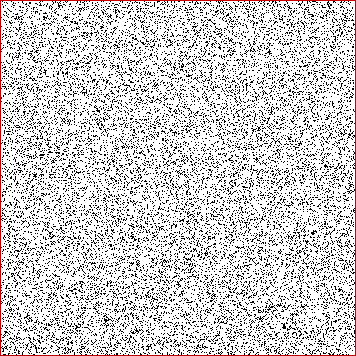

  However, to make the fractal possible, we should add one more rule: *the chosen vertex should not be the same as the previous one*.

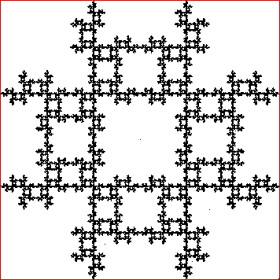

- **Hexagon**: For the **Sierpinksi Hexagon** or hexaflake, the coefficient is $\frac{2}{3}$.

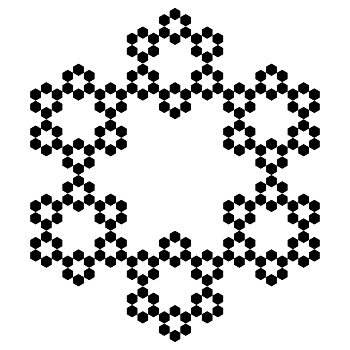

#### **Implementation**

We created a basic shiny app that has 3 parts:

- the User Interface
- the Server part
- the ShinyApp that combines both the UI and the server.

**For the UI**:

- we made a function to print a breakline multiple times.

```
linebreaks <- function(n){HTML(strrep(br(), n))}
```

- used *sidebarLayout()* function to create a layout that contained input in the *sidebarPanel()* for variables such as: the color of the fractal, the number of points and the coefficient. The user can also select the shape of the fractal from the 4 ones.

```
 sidebarLayout(
        sidebarPanel(
            # slider input for the number of drawn points
            sliderInput(inputId = "points",
                        label = "Number of points:",
                        min = 1,
                        max = 10000,
                        value = 1000,
                        sep = ".",
                        #dragRange = TRUE,
                        #interval = 0.0001,
                        #loop = TRUE,
                        #animate = TRUE
            ),

            # slider input for the color of the points
            selectInput(inputId = "color",
                        label = "Color of points:",
                        c("Black" = "black",
                          "Grey" = "gray61",
                          "Red" = "indianred3",
                          "Blue" = "royalblue3",
                          "Purple" = "plum",
                          "Multicolored" = "multi")
            ),

            # slider input for the shape of the polygon
            selectInput(inputId = "shape",
                        label = "Shape of polygon:",
                        c("Triangle" = "tri",
                          "Square" = "sq",
                          "Pentagon" = "penta",
                          "Hexagon" = "hex")
            ),

            # slider input for the coefficient of the distance between the current point and the next one
            selectInput(inputId = "coef",
                        label = "Distance coefficient:",
                        c("1/2" = "1/2",
                          "2/3" = "2/3")
            )
        ),
```

- The **main panel** contains the disired fractal and that was made using the *plotOutput()* function.

```
 mainPanel(
            plotOutput("distPlot")
        )
```

**For the server**:

- we used *renderPlot()* function to render the reactive plot that was assigned to an output slot.
- for each polygon, we set the coordinates from the initial figure, taking into account some mathematical conventions.

```
a <- c(0, 400, 800)
b <- c(0, 800, 0)
```

- with the *par()* function we set the margins of the plot.

```
par(mar = rep(0, 4))
```

- we created the plot with the first 3, 4, 5 or 6 points (vertices) using the basic *plot()* function.

```
plot(a, b, col= "red", pch = 15, cex = 1, axes = FALSE)
```

- we chose the random point that is represented by two coordinates **x and y**.

```
x <- sample(0:800, 1)
y <- sample(0:800, 1)
```

- for chosing a vertex, we used the *sample()* function.

```
vertex <- sample(1:3, 1)
```

- we repeted the process explained above, as many times as the number of points the user selected.
- after finding out the coordinates of the new point, we use the *points()* function to plot the new point.

```
points(x, y, pch = 16, col = input$color, cex = 0.5)
```

#### **Code**

```r
library(shiny)
library(randomcoloR)

linebreaks <- function(n){HTML(strrep(br(), n))}

# Define UI for application
ui <- fluidPage(

    tags$head(tags$link(rel="shortcut icon", href="favicon.ico")),

    # Application title
    h1("THE CHAOS GAME", align = "center"),

    linebreaks(2),


    tags$div(
        HTML(paste(
            tags$h4("You can play with the number of points below: the more points you select, the clearer the fractal will appear."),
            sep = " "

        )
        )
    ),

    linebreaks(1),

    sidebarLayout(
        sidebarPanel(
            # slider input for the number of drawn points
            sliderInput(inputId = "points",
                        label = "Number of points:",
                        min = 1,
                        max = 10000,
                        value = 1000,
                        sep = ".",
                        #dragRange = TRUE,
                        #interval = 0.0001,
                        #loop = TRUE,
                        #animate = TRUE
            ),

            # slider input for the color of the points
            selectInput(inputId = "color",
                        label = "Color of points:",
                        c("Black" = "black",
                          "Grey" = "gray61",
                          "Red" = "indianred3",
                          "Blue" = "royalblue3",
                          "Purple" = "plum",
                          "Multicolored" = "multi")
            ),

            # slider input for the shape of the polygon
            selectInput(inputId = "shape",
                        label = "Shape of polygon:",
                        c("Triangle" = "tri",
                          "Square" = "sq",
                          "Pentagon" = "penta",
                          "Hexagon" = "hex")
            ),

            # slider input for the coefficient of the distance between the current point and the next one
            selectInput(inputId = "coef",
                        label = "Distance coefficient:",
                        c("1/2" = "1/2",
                        "2/3" = "2/3")
            )
        ),

        # Show a plot of the generated distribution
        mainPanel(
            plotOutput("distPlot")
        )
    )
)

# Define server logic required

server <- function(input, output) {

    output$distPlot <- renderPlot({
        # the shape is chosen by the user
        shape = input$shape

        # the distance coefficient is chosen by the user
        # we manipulate its value from string to float
        coef = input$coef
        numerator = strsplit(coef, "/")[[1]][1]
        denominator = strsplit(coef, "/")[[1]][2]
        coef = as.integer(numerator) / as.integer(denominator)

        if (shape == "tri"){
            # Triangle coordinates
            a <- c(0, 400, 800)
            b <- c(0, 800, 0)


            par(mar = rep(0, 4))
            # We draw the coordinates
            plot(a, b, col= "red", pch = 15, cex = 1, axes = FALSE)

            # Random starting point
            x <- sample(0:800, 1)
            y <- sample(0:800, 1)

            # Chaos game
            # Number of points to be drawn
            pct <- input$points
            for (i in 1:pct) {

                # We take a vertex of the triangle at random
                vertex <- sample(1:3, 1)

                # We calculate the coordinates of the next point
                x <- floor(x + (a[vertex] - x) * coef)
                y <- floor(y + (b[vertex] - y) * coef)

                # We add it in the plot

                if (input$color == "multi")
                {
                   color <- randomColor(count = 1, hue = c(" ", "random", "red", "orange", "yellow",
                                  "green", "blue", "purple", "pink", "monochrome"), luminosity = c(" ",
                                  "random", "light", "bright", "dark"))

                   points(x, y, pch = 16, col = color, cex = 0.5)

                }
                else
                {
                    points(x, y, pch = 16, col = input$color, cex = 0.5)
                }

            }
        }
        else
            if (shape == "sq"){
                # Square coordinates
                a <- c(0, 0, 1000, 1000)
                b <- c(0, 1000, 1000, 0)

                par(mar = rep(0, 4))
                # We draw the coordinates
                plot(a, b, col = "red", pch = 15, cex = 1, axes = FALSE)

                # Random starting point
                x <- sample(0:1000, 1)
                y <- sample(0:1000, 1)

                aux = 0 # auxiliary variable to help us check if the previous vertex is the same with the current one

                # Chaos game
                # Number of points to be drawn
                pct <- input$points
                for (i in 1:pct) {
                    # We take a vertex of the square at random
                    vertex <- sample(1:4, 1)

                    # We start the test from the second point
                    if(i != 1)
                    {
                        # We take a new vertex until it differs from the previous one
                        while(aux == vertex)
                        {
                            vertex <- sample(1:4, 1)
                        }
                    }

                    # We update the previous vertex
                    aux = vertex

                    # We calculate the coordinates of the next point
                    x <- floor(x + (a[vertex] - x) * coef)
                    y <- floor(y + (b[vertex] - y) * coef)

                    # We add it in the plot
                    if (input$color == "multi")
                    {
                        color <- randomColor(count = 1, hue = c(" ", "random", "red", "orange", "yellow",
                                  "green", "blue", "purple", "pink", "monochrome"), luminosity = c(" ",
                                  "random", "light", "bright", "dark"))

                        points(x, y, pch = 16, col = color, cex = 0.5)
                    }
                    else
                    {
                        points(x, y, pch = 16, col = input$color, cex = 0.5)
                    }

                }
            }

        else
            if (shape == "penta"){
                # Pentagon coordinates
                    a <- c(550, 455, 491, 609, 645)
                    b <- c(450, 519, 631, 631, 519)

                    par(mar = rep(0, 4))
                    # We draw the coordinates
                    plot(a, b, col= "red", pch = 15, cex = 1, axes = FALSE)

                    # Random starting point
                    x <- sample(0:645, 1)
                    y <- sample(0:631, 1)

                    # Chaos game
                    # Number of points to be drawn
                    pct <- input$points

                    aux = 0

                    for (i in 1:pct) {

                        # We take a vertex of the hexagon at random
                        vertex <- sample(1:5, 1)

                        if(i != 1)
                        {
                            # We take a new vertex until it differs from the previous one
                            while(aux == vertex)
                            {
                                vertex <- sample(1:5, 1)
                            }
                        }

                        aux = vertex

                        # We calculate the coordinates of the next point
                        x <- floor(x + (a[vertex] - x) * coef)
                        y <- floor(y + (b[vertex] - y) * coef)

                        # We add it in the plot
                        if (input$color == "multi")
                        {
                            color <- randomColor(count = 1, hue = c(" ", "random", "red", "orange", "yellow",
                                      "green", "blue", "purple", "pink", "monochrome"), luminosity = c(" ",
                                      "random", "light", "bright", "dark"))

                            points(x, y, pch = 16, col = color, cex = 0.5)
                        }

                        else
                        {
                            points(x, y, pch = 16, col = input$color, cex = 0.5)
                        }
                    }


            }
            else
                if (shape == "hex"){
                    # Hexagon coordinates
                    a <- c(500, 1500, 2000,1500,500,0)
                    b <- c(0, 0, 866.025,1732.05,1732.05,866.025)

                    par(mar = rep(0, 4))
                    # We draw the coordinates
                    plot(a, b, col= "red", pch = 15, cex = 1, axes = FALSE)

                    # Random starting point
                    x <- sample(0:1000, 1)
                    y <- sample(0:1000, 1)

                    # Chaos game
                    # Number of points to be drawn
                    pct <- input$points
                    for (i in 1:pct) {

                        # We take a vertex of the hexagon at random
                        vertex <- sample(1:6, 1)

                        # We calculate the coordinates of the next point
                        x <- floor(x + (a[vertex] - x) * coef)
                        y <- floor(y + (b[vertex] - y) * coef)

                        # We add it in the plot
                        if (input$color == "multi")
                        {
                            color <- randomColor(count = 1, hue = c(" ", "random", "red", "orange", "yellow",
                                      "green", "blue", "purple", "pink", "monochrome"), luminosity = c(" ",
                                      "random", "light", "bright", "dark"))

                            points(x, y, pch = 16, col = color, cex = 0.5)
                        }
                        else
                        {
                            points(x, y, pch = 16, col = input$color, cex = 0.5)
                        }
                    }
                }

    })
}

# Run the application
shinyApp(ui = ui, server = server)
```

Shiny applications not supported in static R Markdown documents

### **References**

1. http://math.bu.edu/DYSYS/chaos-game/chaos-game.html
2. https://datascienceplus.com/wp-content/uploads/2017/10/How-to-start-with-ShinyR.pdf
3. https://shiny.rstudio.com/articles/sliders.html
4. https://rmarkdown.rstudio.com/lesson-1.html
5. https://shiny.rstudio.com/reference/shiny/latest/plotOutput.html
6. https://scratch.mit.edu/studios/3676382/
7. https://en.wikipedia.org/wiki/Chaos_game
8. https://bentrubewriter.com/2012/06/14/post-100-fractal-fairy-tales/
9. https://en.wikipedia.org/wiki/Fractal